# Lab 24: In-Class

Claire Donnat

8/20/2020

# Classification

We load the following datsets including characteristics of emails and spams:

- 48 continuous real [0,100] attributes of type

`word_freq_WORD = percentage of words in the e-mail that match WORD.

- 6 continuous real [0,100] attributes of type

`char_freq_CHAR` = percentage of characters in the e-mail that match CHAR,

- 1 continuous real [1,...] attribute of type `capital_run_length_average` = average length of uninterrupted sequences of capital letters
- 1 continuous integer [1,...] attribute of type

`capital_run_length_longest` = length of longest uninterrupted sequence of capital letters

- 1 continuous integer [1,...] attribute of type

`capital_run_length_total` = sum of length of uninterrupted sequences of capital letters = = total number of capital letters in the e-mail

- 1 nominal {0,1} class attribute of type

`spam` = denotes whether the e-mail was considered spam (1) or not (0),

```r
url.info <- "https://archive.ics.uci.edu/ml/machine-learning-databases/spambase/spambase.names"
spam.info <- read.table(url.info, comment.char = "|", skip = 32, stringsAsFactors = FALSE)
attributes <- gsub(":", "", spam.info[[1]])
symbols <- c("semicolon", "left.parenthesis", "left.sq.bracket", "exclamation",
             "dollar", "hashtag")
attributes[49: 54] <- paste0("char_freq_", symbols)
```

```r
url.data <- "https://archive.ics.uci.edu/ml/machine-learning-databases/spambase/spambase.data"
spam <- read.csv(url.data, header = FALSE, stringsAsFactors = FALSE)
colnames(spam) <- c(attributes, "spam")
spam <- spam %>%
  mutate(spam  = factor(spam, levels = c(0, 1), labels = c("email", "spam")))
```

1. Check if the dataset contains balance classes spam vs email. To do this count the cases of spam and email, and make a barplot for the frequencies.

```r
print(spam %>%
  group_by(spam)%>%
  tally() )
```

```
## # A tibble: 2 x 2
##   spam      n
##   <fct> <int>
## 1 email  2788
## 2 spam   1813
```

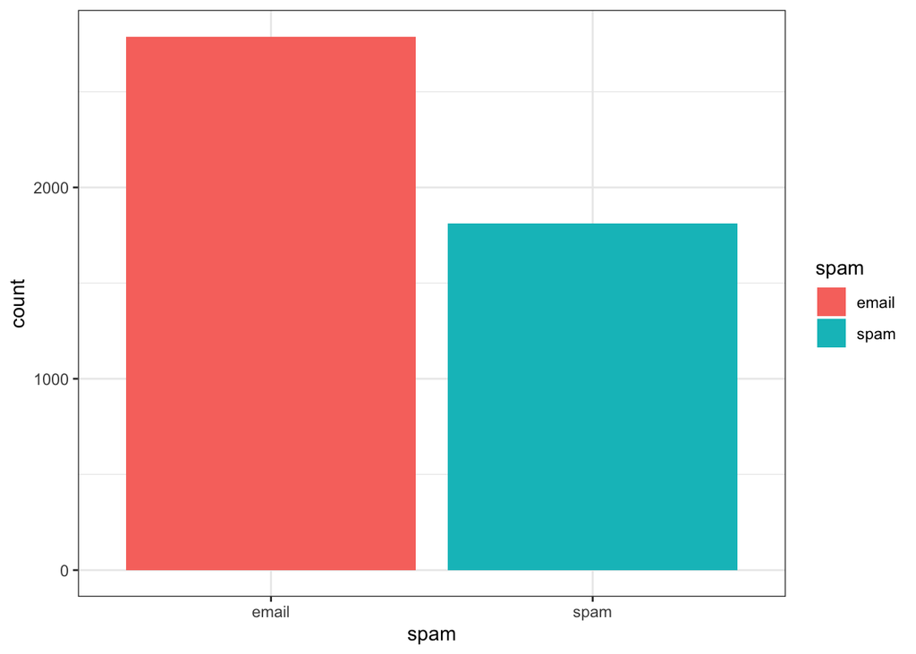

```r
ggplot(spam, aes(x=spam, fill=spam))+
  geom_bar()+
  theme_bw()
```

2. Divide the data into train and test set with a 60%-40% split. Remember to record the seed you used for randomization.

```r
set.seed(1234)
train_index = sample(1:nrow(spam), floor(0.60 *nrow(spam)))
test_index = setdiff(1:nrow(spam), train_index)
```

3. Use logistic regression involving all the predictors to train a model for classifying emails. Which features seem significant? Evaluate and report your model's accuracy on the test set.

```r
summary( log.reg <- glm(spam ~ ., data=spam[train_index,], family=binomial))
```

```
##
## Call:
## glm(formula = spam ~ ., family = binomial, data = spam[train_index,
##     ])
##
## Deviance Residuals:
##     Min       1Q   Median       3Q      Max
## -4.4470  -0.2011   0.0000   0.1104   3.9758
##
## Coefficients:
##                              Estimate Std. Error z value Pr(>|z|)
## (Intercept)                -2.151e+00  2.287e-01  -9.407  < 2e-16 ***
## word_freq_make             -5.397e-01  3.404e-01  -1.586 0.112821
## word_freq_address          -1.244e-01  8.809e-02  -1.412 0.158011
## word_freq_all               2.331e-01  1.586e-01   1.470 0.141543
## word_freq_3d                1.445e+00  1.823e+00   0.793 0.427956
## word_freq_our               5.769e-01  1.353e-01   4.265 2.00e-05 ***
## word_freq_over              7.246e-01  3.134e-01   2.312 0.020791 *
## word_freq_remove            1.693e+00  3.877e-01   4.366 1.26e-05 ***
## word_freq_internet          5.474e-01  2.265e-01   2.417 0.015659 *
## word_freq_order             5.779e-01  4.267e-01   1.355 0.175567
## word_freq_mail              3.883e-02  1.099e-01   0.353 0.723896
## word_freq_receive          -3.037e-01  3.999e-01  -0.759 0.447646
## word_freq_will             -1.961e-01  1.088e-01  -1.803 0.071364 .
## word_freq_people            1.034e-01  3.204e-01   0.323 0.746892
## word_freq_report            4.776e-02  1.818e-01   0.263 0.792821
## word_freq_addresses         3.074e+00  1.632e+00   1.884 0.059622 .
## word_freq_free              1.132e+00  2.062e-01   5.488 4.07e-08 ***
## word_freq_business          1.074e+00  2.848e-01   3.771 0.000163 ***
## word_freq_email             1.883e-01  1.689e-01   1.115 0.264821
## word_freq_you               1.356e-01  4.852e-02   2.796 0.005181 **
## word_freq_credit            7.692e-01  6.256e-01   1.230 0.218847
## word_freq_your              2.205e-01  7.452e-02   2.959 0.003081 **
## word_freq_font              1.816e-01  2.366e-01   0.767 0.442809
## word_freq_000               2.174e+00  5.932e-01   3.664 0.000248 ***
## word_freq_money             5.093e-01  2.687e-01   1.895 0.058038 .
## word_freq_hp               -1.596e+00  3.299e-01  -4.836 1.33e-06 ***
## word_freq_hpl              -1.112e+00  5.942e-01  -1.871 0.061287 .
## word_freq_george           -1.671e+01  3.537e+00  -4.725 2.30e-06 ***
## word_freq_650               7.252e-01  3.335e-01   2.174 0.029678 *
```

[output cut: 24 more lines]

```
## char_freq_dollar            4.736e+00  8.992e-01   5.267 1.39e-07 ***
## char_freq_hashtag           1.957e+00  1.142e+00   1.714 0.086585 .
## capital_run_length_average  2.092e-01  7.587e-02   2.758 0.005822 **
## capital_run_length_longest  8.186e-03  4.106e-03   1.994 0.046195 *
## capital_run_length_total    7.755e-04  2.938e-04   2.640 0.008301 **
## ---
## Signif. codes:  0 '***' 0.001 '**' 0.01 '*' 0.05 '.' 0.1 ' ' 1
##
## (Dispersion parameter for binomial family taken to be 1)
##
##     Null deviance: 3694.7  on 2759  degrees of freedom
## Residual deviance: 1038.3  on 2702  degrees of freedom
## AIC: 1154.3
##
## Number of Fisher Scoring iterations: 23
```

```r
preds  = (predict(log.reg, spam[test_index,]) >0) * 1
print(accuracy <- mean(preds == 1*(spam$spam[test_index] == 1)))
```

```
## [1] 0.6110809
```

```r
#import the package
library(randomForest)
# Perform training:
rf_classifier = randomForest(spam ~ ., data=spam[train_index,], ntree=100, mtry=2, importance=TRUE)
print(rf_classifier)
```

```
##
## Call:
##  randomForest(formula = spam ~ ., data = spam[train_index, ],      ntree = 100, mtry = 2, importance = TRUE)
##                Type of random forest: classification
##                      Number of trees: 100
## No. of variables tried at each split: 2
##
##         OOB estimate of  error rate: 6.3%
## Confusion matrix:
##       email spam class.error
## email  1621   59  0.03511905
## spam    115  965  0.10648148
```

```r
preds  = predict(rf_classifier, spam[test_index,])
print(mean(preds == spam$spam[test_index]))
```

```
## [1] 0.9386203
```

# Exercise 2: Random Forest

In this exercise we will build a random forest model based on the data used to create the visualization [here](http://www.r2d3.us/visual-intro-to-machine-learning-part-1/).

```r
# Skip first 2 lines since they were comments
url <- paste0("https://raw.githubusercontent.com/jadeyee/r2d3-part-1-data/",
              "master/part_1_data.csv")
houses <- read.csv(url, skip = 2)
houses <- tbl_df(houses)
houses <- houses %>%
    mutate(city = factor(in_sf, levels = c(1, 0), labels = c("SF", "NYC")))
houses
```

```
## # A tibble: 492 x 9
##    in_sf  beds  bath   price year_built  sqft price_per_sqft elevation city
##    <int> <dbl> <dbl>   <int>      <int> <int>          <int>     <int> <fct>
##  1     0     2     1  999000       1960  1000            999        10 NYC
##  2     0     2     2 2750000       2006  1418           1939         0 NYC
##  3     0     2     2 1350000       1900  2150            628         9 NYC
##  4     0     1     1  629000       1903   500           1258         9 NYC
##  5     0     0     1  439000       1930   500            878        10 NYC
##  6     0     0     1  439000       1930   500            878        10 NYC
##  7     0     1     1  475000       1920   500            950        10 NYC
##  8     0     1     1  975000       1930   900           1083        10 NYC
##  9     0     1     1  975000       1930   900           1083        12 NYC
## 10     0     2     1 1895000       1921  1000           1895        12 NYC
## # … with 482 more rows
```

1. Using `pairs()` function plot the relationship between every variable pairs. You can color the points by the city the observation corresponds to; set the color argument in `pairs()` as follows: `col = houses$in_sf + 3L`

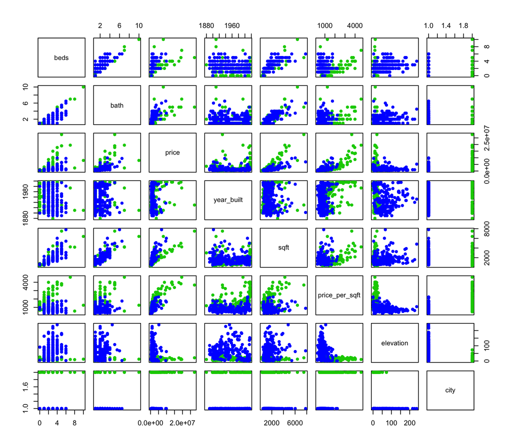

```r
city.colors <- houses$in_sf + 3L
pairs(houses[, -1], col = city.colors, pch = 16)
```

2. Split the data into (70%-30%) train and test set. How many observations are in your train and test sets?

```r
set.seed(123)
train.idx <- sample(nrow(houses), 0.7 * nrow(houses))
train <- houses[train.idx, ]
test <- houses[-train.idx, ]
dim(train)
```

```
## [1] 344   9
```

```r
dim(test)
```

```
## [1] 148   9
```

3. Train a random forest on the train set, using all the variables in the model, to classify houses into the ones from San Francisco and from New York. Remember to remove 'in_sf', as it is the same variable as 'city'.

```r
library(randomForest)
houses.rf <- randomForest(city ~ . -in_sf, data = train, importance = TRUE, proximity = TRUE)
houses.rf
```

```
##
## Call:
##  randomForest(formula = city ~ . - in_sf, data = train, importance = TRUE,      proximity = TRUE)
##                Type of random forest: classification
##                      Number of trees: 500
## No. of variables tried at each split: 2
##
##         OOB estimate of  error rate: 10.47%
## Confusion matrix:
##      SF NYC class.error
## SF  172  21  0.10880829
## NYC  15 136  0.09933775
```

# Exercise 3: Logistic Regression

In this you will use a dataset `Default`, on customer default records for a credit card company, which is included in ISL book. To obtain the data you will need to install a package `ISLR`.

```r
# install.packages("ISLR")
library(ISLR)
(Default <- tbl_df(Default))
```

```
## # A tibble: 10,000 x 4
##    default student balance income
##    <fct>   <fct>     <dbl>  <dbl>
##  1 No      No         730. 44362.
##  2 No      Yes        817. 12106.
##  3 No      No        1074. 31767.
##  4 No      No         529. 35704.
##  5 No      No         786. 38463.
##  6 No      Yes        920.  7492.
##  7 No      No         826. 24905.
##  8 No      Yes        809. 17600.
##  9 No      No        1161. 37469.
## 10 No      No           0  29275.
## # … with 9,990 more rows
```

1. First, divide your dataset into a train and test set. Randomly sample 6000 observations and include them in the train set, and the remaining use as a test set.

```r
train.idx <- sample(1:nrow(Default), 6000, replace = FALSE)
train <- Default[train.idx, ]
test <- Default[-train.idx, ]
```

2. Fit a logistic regression including all the features to predict whether a customer defaulted or not.

```r
fit.logit <- glm(default ~ student + balance + income, data = train,
                 family = "binomial")
summary(fit.logit)
```

```
##
## Call:
## glm(formula = default ~ student + balance + income, family = "binomial",
##     data = train)
##
## Deviance Residuals:
##     Min       1Q   Median       3Q      Max
## -2.5098  -0.1508  -0.0600  -0.0223   3.6766
##
## Coefficients:
##               Estimate Std. Error z value Pr(>|z|)
## (Intercept) -1.121e+01  6.314e-01 -17.761   <2e-16 ***
## studentYes  -3.383e-01  3.021e-01  -1.120   0.2628
## balance      5.633e-03  2.928e-04  19.236   <2e-16 ***
## income       1.696e-05  1.022e-05   1.659   0.0971 .
## ---
## Signif. codes:  0 '***' 0.001 '**' 0.01 '*' 0.05 '.' 0.1 ' ' 1
##
## (Dispersion parameter for binomial family taken to be 1)
##
##     Null deviance: 1773.89  on 5999  degrees of freedom
## Residual deviance:  979.81  on 5996  degrees of freedom
## AIC: 987.81
##
## Number of Fisher Scoring iterations: 8
```

3. Note if any variables seem not significant. Then, adjust your model accordingly (by removing them).

```r
fit.logit <- glm(default ~ student + balance, data = train,
                 family = "binomial")
summary(fit.logit)
```

```
##
## Call:
## glm(formula = default ~ student + balance, family = "binomial",
##     data = train)
##
## Deviance Residuals:
##     Min       1Q   Median       3Q      Max
## -2.4481  -0.1507  -0.0601  -0.0223   3.7017
##
## Coefficients:
##               Estimate Std. Error z value Pr(>|z|)
## (Intercept) -1.053e+01  4.603e-01 -22.865  < 2e-16 ***
## studentYes  -7.259e-01  1.878e-01  -3.865 0.000111 ***
## balance      5.634e-03  2.921e-04  19.288  < 2e-16 ***
## ---
## Signif. codes:  0 '***' 0.001 '**' 0.01 '*' 0.05 '.' 0.1 ' ' 1
##
## (Dispersion parameter for binomial family taken to be 1)
##
##     Null deviance: 1773.89  on 5999  degrees of freedom
## Residual deviance:  982.58  on 5997  degrees of freedom
## AIC: 988.58
##
## Number of Fisher Scoring iterations: 8
```

4. Compute the predicted probabilities of 'default' for the observations in the test set. Then evaluate the model accuracy.

```r
pred.prob.default <- predict(fit.logit, test, type = "response")
pred.default <- factor(pred.prob.default > 0.5, levels = c(FALSE, TRUE),
                       labels = c( "No", "Yes"))
(tab <- table(pred = pred.default, true = test$default))
```

```
##      true
## pred    No  Yes
##   No  3856   82
##   Yes   14   48
```

```r
(accuracy <- sum(diag(tab))/nrow(test))
```

```
## [1] 0.976
```

4. For the test set, generate a scatterplot of 'balance' vs 'default' with points colored by 'student' factor. Then, overlay a line plot of the predicted probability of default as computed in the previous question. You should plot two lines for student and non student separately by setting the 'color = student'.

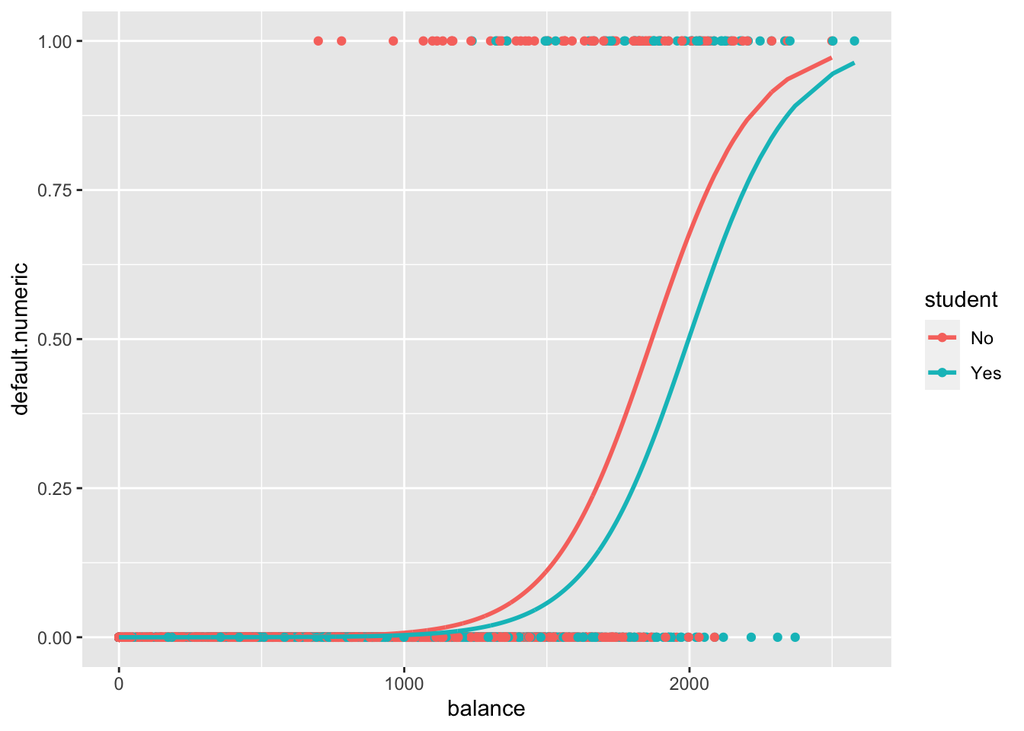

```r
train$default.numeric <- as.numeric(train$default) - 1
test$default.numeric <- as.numeric(test$default) - 1

ggplot(test, aes(x = balance, color = student)) +
  geom_point(aes(y = default.numeric)) +
  geom_line(aes(y = pred.prob.default), lwd = 1)
```

# Exercise 4: Hypothesis testing

Similarly to dataset `mtcars`, the dataset `mpg` from `ggplot` package includes data on automobiles. However, `mpg` includes data for newer cars from year 1999 and 2008. The variables measured for each car is slighly different. Here we are interested in the variable, `hwy`, the highway miles per gallon.

```r
# We first format the column trans to contain only info on transmission auto/manual
mpg
```

```
## # A tibble: 234 x 11
##    manufacturer model    displ  year   cyl trans   drv     cty   hwy fl    class
##    <chr>        <chr>    <dbl> <int> <int> <chr>   <chr> <int> <int> <chr> <chr>
##  1 audi         a4         1.8  1999     4 auto(l… f        18    29 p     comp…
##  2 audi         a4         1.8  1999     4 manual… f        21    29 p     comp…
##  3 audi         a4         2    2008     4 manual… f        20    31 p     comp…
##  4 audi         a4         2    2008     4 auto(a… f        21    30 p     comp…
##  5 audi         a4         2.8  1999     6 auto(l… f        16    26 p     comp…
##  6 audi         a4         2.8  1999     6 manual… f        18    26 p     comp…
##  7 audi         a4         3.1  2008     6 auto(a… f        18    27 p     comp…
##  8 audi         a4 quat…   1.8  1999     4 manual… 4        18    26 p     comp…
##  9 audi         a4 quat…   1.8  1999     4 auto(l… 4        16    25 p     comp…
## 10 audi         a4 quat…   2    2008     4 manual… 4        20    28 p     comp…
## # … with 224 more rows
```

```r
mpg <- mpg %>%
  mutate(
    transmission = factor(
        gsub("\\((.*)", "", trans), levels = c("auto", "manual"))
  )
mpg
```

```
## # A tibble: 234 x 12
##    manufacturer model displ  year   cyl trans drv     cty   hwy fl    class
##    <chr>        <chr> <dbl> <int> <int> <chr> <chr> <int> <int> <chr> <chr>
##  1 audi         a4      1.8  1999     4 auto… f        18    29 p     comp…
##  2 audi         a4      1.8  1999     4 manu… f        21    29 p     comp…
##  3 audi         a4      2    2008     4 manu… f        20    31 p     comp…
##  4 audi         a4      2    2008     4 auto… f        21    30 p     comp…
##  5 audi         a4      2.8  1999     6 auto… f        16    26 p     comp…
##  6 audi         a4      2.8  1999     6 manu… f        18    26 p     comp…
##  7 audi         a4      3.1  2008     6 auto… f        18    27 p     comp…
##  8 audi         a4 q…   1.8  1999     4 manu… 4        18    26 p     comp…
##  9 audi         a4 q…   1.8  1999     4 auto… 4        16    25 p     comp…
## 10 audi         a4 q…   2    2008     4 manu… 4        20    28 p     comp…
## # … with 224 more rows, and 1 more variable: transmission <fct>
```

## Part 1: One-sample test

1. Subset the `mpg` dataset to inlude only cars from year 2008.

```r
mpg2008 <- mpg %>%
  filter(year == 2008)
```

2. Test whether cars from 2008 have mean the highway miles per gallon, `hwy`, equal to 30 mpg.

```r
t.test(mpg2008$hwy, mu = 30, alternative = "two.sided")
```

```
##
##  One Sample t-test
##
## data:  mpg2008$hwy
## t = -12.11, df = 116, p-value < 2.2e-16
## alternative hypothesis: true mean is not equal to 30
## 95 percent confidence interval:
##  22.38218 24.52380
## sample estimates:
## mean of x
##  23.45299
```

3. Test whether cars from 2008 with 4 cylinders have mean `hwy` equal to 30 mpg.

```r
mpg2008_4cyl <- mpg %>%
  filter(year == 2008, cyl == 4)

t.test(mpg2008_4cyl$hwy, mu = 30, alternative = "two.sided")
```

```
##
##  One Sample t-test
##
## data:  mpg2008_4cyl$hwy
## t = -1.1492, df = 35, p-value = 0.2582
## alternative hypothesis: true mean is not equal to 30
## 95 percent confidence interval:
##  28.15568 30.51098
## sample estimates:
## mean of x
##  29.33333
```

## Part 2: Two-sample test

1. Test if the mean `hwy` for automatic is **less than** that for manual cars **in 2008**. Generate a boxplot with jittered points for `hwy` for each transmission group.

```r
t.test(data = mpg2008, hwy ~ transmission, alternative = "less")
```

```
##
##  Welch Two Sample t-test
##
## data:  hwy by transmission
## t = -3.1269, df = 64.928, p-value = 0.001322
## alternative hypothesis: true difference in means is less than 0
## 95 percent confidence interval:
##       -Inf -1.635703
## sample estimates:
##   mean in group auto mean in group manual
##             22.43373             25.94118
```

```r
# or
# t.test(x = mpg2008 %>% filter(transmission == "auto") %>% pull(hwy),
#        y = mpg2008 %>% filter(transmission == "manual") %>% pull(hwy),
#        alternative = "less")
```

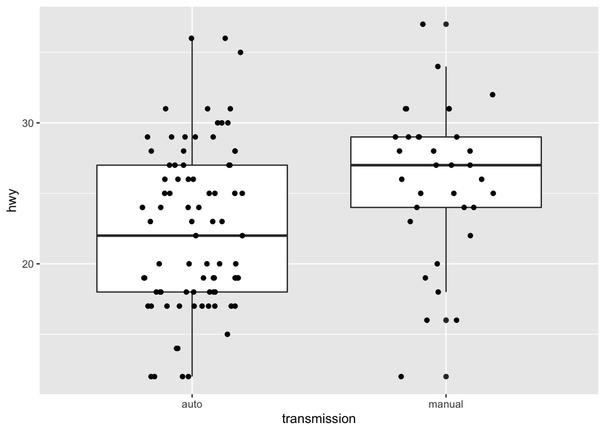

```r
ggplot(mpg2008, aes(x = transmission, y = hwy)) +
  geom_boxplot() + geom_jitter(height = 0, width = 0.2)
```

2. Test if the mean `hwy` for cars from 1999 and is greater than that for cars from 2008. Generate a boxplot with jittered points for `hwy` for each year group.

```r
t.test(data = mpg, hwy ~ year, alternative = "greater")
```

```
##
##  Welch Two Sample t-test
##
## data:  hwy by year
## t = -0.032864, df = 231.64, p-value = 0.5131
## alternative hypothesis: true difference in means is greater than 0
## 95 percent confidence interval:
##  -1.314123       Inf
## sample estimates:
## mean in group 1999 mean in group 2008
##           23.42735           23.45299
```

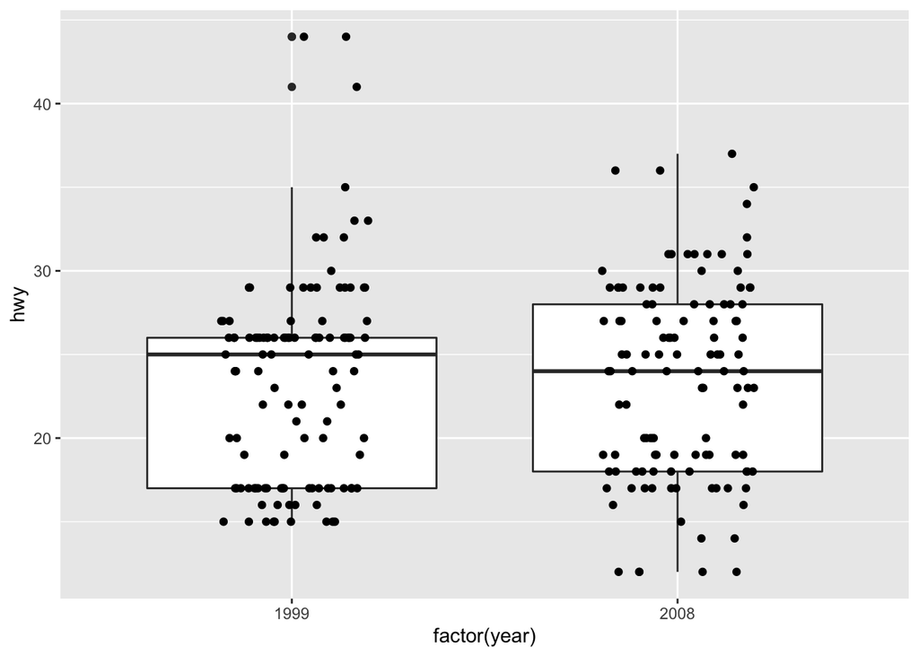

```r
ggplot(mpg, aes(x = factor(year), y = hwy)) +
  geom_boxplot() + geom_jitter(height = 0, width = 0.2)
```